# P5

Jonathan Jeng

## 1. What is our independent variable? What is our dependent variable?

The variable we can control and which is independent of any other aspect of our experiment is the test condition (i.e., **congruent words** or **incongruent words**).

The variable we do not directly control and which we surmise is dependent on aspects of our experiment (e.g., the test condition) is the time it takes to name text colors.

## 2. What is an appropriate set of hypotheses for this task? What kind of statistical test do you expect to perform? Justify your choices.

Hypotheses:

- $H_{0}$ (null hypothesis): there is no difference between the time it takes to name text colors of congruent words (color words whose names match the color of the text) and incongruent words (color words whose names don’t match the color of the text). In order for performance comparison using statistical t-tests, performance will be portrayed as a single number - the average performance - so in other words, $H_{0}: \mu_{c} = \mu_{i}$ where $\mu_{c}$ represents the average time taken to complete the test with congruent words and $\mu_{i}$ represents that average time taken to complete the test with incongruent words.
- $H_{a}$ (alternative hypothesis): the time it takes to name text colors of congruent words is not equal to the time it takes to name text colors of incongruent words. In other words, $H_{a}: \mu_{c} \neq \mu_{i}$. If we approach this scenario naively, it may not be apparent that performance on one assessment should be superior to performance on the other, so instead of hypothesizing that performance on one specific assessment is superior, we simply hypothesize that performance on any one of the two may be superior and our performance measures are thus not equal.

To test the verity of the above hypotheses, we’ll perform a two-tailed paired t-test. The corresponding reasoning is as follows: * **two-tailed**: Since our alternative hypothesis is that the two measures are not equal (i.e., that either may be less than the other, not that one specific measure is less than another), our test will be a two-tailed test, rather than a one-tailed test. If we proceed with a confidence level of $\alpha = 0.05$, then since we have exactly 24 observations, as can be seen below, we have 23 degrees of freedom and thus a t-critical value of $\pm2.068658$ given our alpha level, according to the below. We’ll evaluate our test statistic (i.e., t-statistic) against this confidence level in order to conclude whether to retain the null hypothesis or reject it in favor of the alternative hypothesis. * **paired**: Our tested populations are one and the same - an individual takes the assessment with congruent words, then at a later time, the same individual takes the assessment with incongruent words - and so we have only one population sample that produces results that may be paired (e.g., a result on one assessment corresponds with specifically one another result on the second assessment by virtue of the individual responsible for taking the assessment). * **t-test**: The t-test follows a t distribution, which is inherently suited to a higher degree of error, as is shown by the below plot (code taken directly from [statmethods.net](https://www.statmethods.net/advgraphs/probability.html)). As is apparent, the distribution is wider with fewer degrees of freedom and approaches the relatively tall, narrow normal curve as the number of degrees of freedom approaches 30. Thus, a t-test is suitable for limited sample sizes (i.e., $n < 30$; if $n \geq 30$, then the t distribution approximates a normal distribution and is thus not especially suited to the circumstances; in such a case, it may be worth deliberating a different test). The t distribution is also relatively wide and therefore more accommodating of error, as with variable (e.g., possibly large) standard deviations. In this case, our sample size is quite small (the current sample sizes are 24, as is illustrated when we read in the data below) and we do not know parameters of the underlying population, such as the standard deviation of the scores, so the t-test seems advisable.

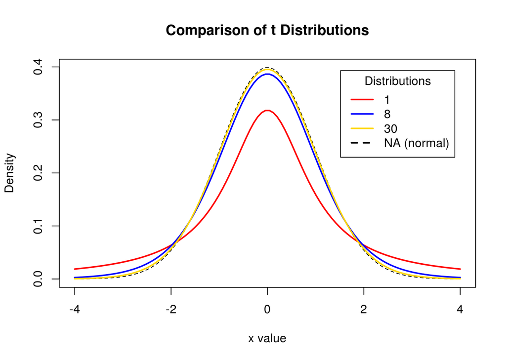

```
## [1] "Critical value: positive or negative 2.06865761041905"
```

```
## [1] "Number of observations: 24"
```

## 3. Report some descriptive statistics regarding this dataset. Include at least one measure of central tendency and at least one measure of variability.

Five number summaries and means (all figures are measures of seconds):

```
##    Congruent      Incongruent
##  Min.   : 8.63   Min.   :15.69
##  1st Qu.:11.90   1st Qu.:18.72
##  Median :14.36   Median :21.02
##  Mean   :14.05   Mean   :22.02
##  3rd Qu.:16.20   3rd Qu.:24.05
##  Max.   :22.33   Max.   :35.26
```

Standard deviations (all figures are measures of seconds):

```
##   Congruent Incongruent
##    3.559358    4.797057
```

In other words, if we use “average” as a measure of central tendency, we have (approximately): * Congruent: 14.05 seconds * Incongruent: 22.02 seconds

If we use “median” as a measure of central tendency, we have (approximately): * Congruent: 14.36 seconds * Incongruent: 21.02 seconds

If we use “standard deviation” as a measure of variability, we have (approximately): * Congruent: 3.56 seconds * Incongruent: 4.80 seconds

If we use “IQR” as a measure of variability, we have (approximately) * Congruent: 4.30 seconds * Incongruent: 5.33 seconds

## 4. Provide one or two visualizations that show the distribution of the sample data. Write one or two sentences noting what you observe about the plot or plots.

Below, we visualize the data with density curves (average values are superimposed for reference).

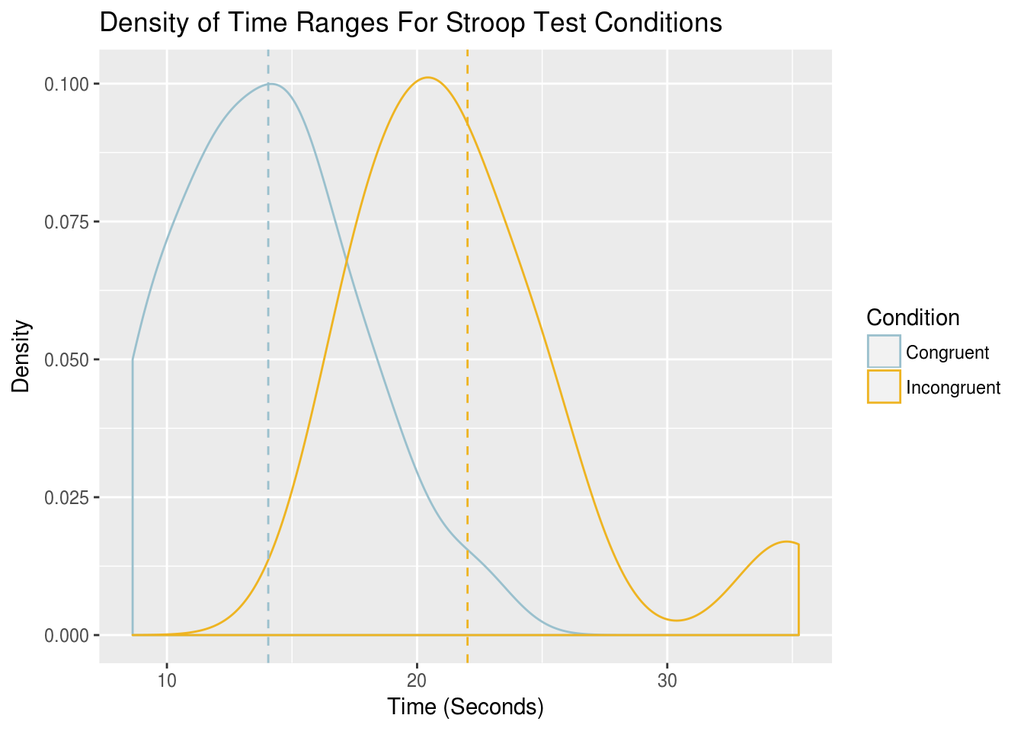

We see that the times taken to complete the test given each test condition do overlap to a great extent, but also appear quite different. We also see that the mean values also differ to quite some extent.

Below, we view a violin of the given data with the 25th, 50th, and 75th quantiles included and extreme values (i.e., times greater than 30 seconds). Frankly, the information therein is redundant, but whereas the above plot emphasizes the overlap in performance given each condition, the below emphasizes the degree of difference in performance. The removal of seemingly abnormally large values changes exact density values but does not change relative positioning of the groups. We see that all members of the middle 50% of the performances scores corresponding to the “incongruent words” condition are strictly greater than all members of the middle 50% of the performances scores corresponding to the “congruent words” condition. We still see quite some degree of overlap but this visualization is quite suggestive that performance on the assessment with the “incongruent words” condition is substantially inferior. Again, the average values are included and we see quite a stark difference between the two values.

We also see more readily that the distributions are right-skewed, though this fact is does not seem to apply to the distribution of scores corresponding to scores on the assessment with the “incongruent words” condition once extremely large are removed.

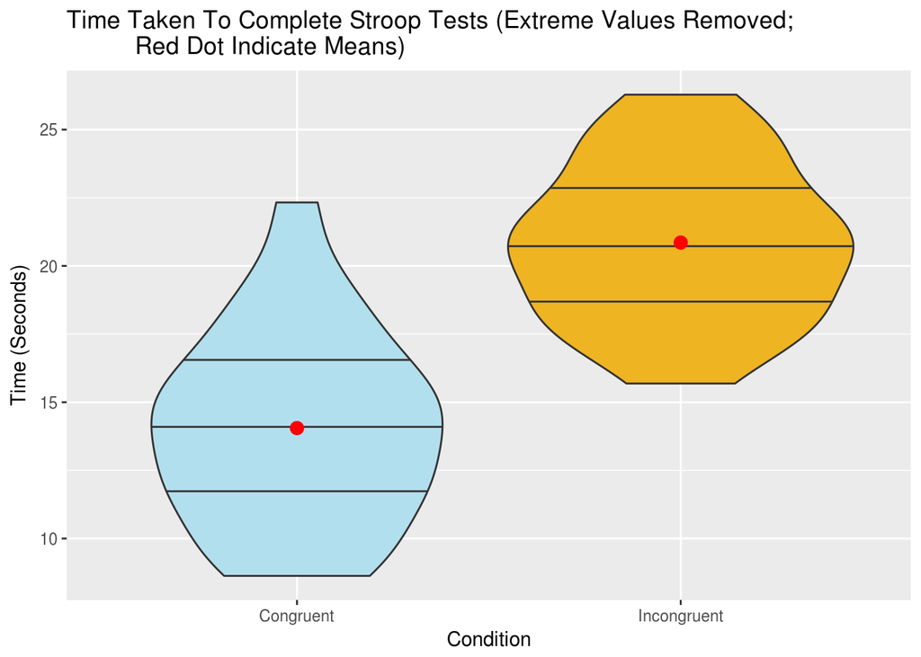

## 5. Now, perform the statistical test and report your results. What is your confidence level and your critical statistic value? Do you reject the null hypothesis or fail to reject it? Come to a conclusion in terms of the experiment task. Did the results match up with your expectations?

```
## Congruent
##  4.864827
```

Given the above, our t-statistic is: $\frac{14.05 - 22.02}{0.99} \approx -8.02$. This is far lesser than our critical value of $-2.069$ and has a p-value of approximately $4.1 * 10^{-8}$, as the following finds.

```
## [1] 4.109218e-08
```

Of course, these are approximate values, as we often rounded our results. More exact figures are used below to find a p-value of, again, approximately $4.1 * 10^{-8}$

```
##    Congruent
## 4.103001e-08
```

A shorter way of finding the above, yet still with exact figures, is as follows:

```
##
##  Paired t-test
##
## data:  stroop_df$Congruent and stroop_df$Incongruent
## t = -8.0207, df = 23, p-value = 4.103e-08
## alternative hypothesis: true difference in means is not equal to 0
## 95 percent confidence interval:
##  -10.019028  -5.910555
## sample estimates:
## mean of the differences
##               -7.964792
```

To reiterate, we used a two-tailed paired t-test, obtained a t value of $t(23) \approx -8.02$. With 23 degrees of freedom, this has a probability (e.g., p-value) of approximately $4.10 * 10^{-8}$ (i.e., $p < 0.05$), so at an alpha level of 0.05, we reject the null hypothesis in favor of the alternative hypothesis. In other words, the time it takes to name text colors of congruent words is not equal to the time it takes to name text colors of incongruent words.

At a confidence level of 95%, our confidence interval on the mean difference is approximately (-10.02, -5.91). This can also be taken from the above or calculated as follows:

```
## [1] "Confidence interval: (-10.0190279093649, -5.91055542396841)"
```

The effect size measures are:

- $r^{2}$: $\frac{-8.02^{2}}{-8.02^{2} + 23} \approx 0.74$, as is illustrated below:

```
## Congruent
## 0.7366364
```

- Cohen’s d: $\frac{-7.96}{4.87} \approx -1.64$, as is illustrated below:

```
## Congruent
##  -1.63722
```

This aligns with my expectations based on the above visualizations and experience. Based on the above plots, it seems that performance given one test condition varied widely from that given the other test condition.

Further, it seems that color recognition is a more prominent cognitive function than is the deliberate reading of text. When creating plots, it is common to differentiate points by use of color because the human visual system discerns color so quickly and automatically. On the other hand, text may be used to label groups of points, but it is not common to see individual points differentiated by use of text labels. If individuals are asked to read text but antagonistic color information is added to the mix, it is clear that performance will be substantially degraded.

One can also consult concepts suggested in neuroanatomy. Relevant processing for color occurs in early visaul areas - V4 and color discrimination arguably occurs in V1. In contrast, reading involves later stages of the visual system - one may discriminate as early as in V1, but characters must be recognized as such (i.e., as objects), the directionality of text must be distinguished, and etc. One may argue that therefore, one can recognize color more quickly and will be less accurate when reading text of disparate information. The earlier interpreted information (e.g., color category) must be deliberately rejected in favor of information gleaned from reading the text, and this will take time. Further, this need for deliberate rejection also implies decreased accuracy.

To be fair, the results may be in line with nuanced expectations but are by no means conclusive and may not generalize to the population at large.

One area of concern is that the sampled population may not be representative of the population at large. No data is provided regarding the sampled individuals. It may well be the case that the a subset of the population, such as those that spend much more time reasoning and/or engage in seemingly inconsequential tests found on obscure websites, perform worse given the test condition of “incongruent words” than does the rest of the population. The sampled population may be more accustomed to tasks involving reading (e.g., from visiting a greater portion of text-based websites) and thereforefore performed at a different level than does the rest of the population when contradictory color information is introduced. Since, the population was not sampled randomly, it seems some lack of representativeness is likely.

Also, the tests were not conducted in controlled environments. It seems possible that at least a portion of those sampled completed tests with each test condition while in different environments (e.g., one portion at a coffee shop and another at home).

Further, statistical t-tests presume certain characteristics of the data, such as that the data is approximately normally distributed. One may argue that data regarding the “incongruent words” test condition are *approximately* normally distributed (outliers render this questionable), but it is more difficult to argue that data regarding the “congruent words” test condition are normally distributed. Thus, one may not choose to trust the results of this test.

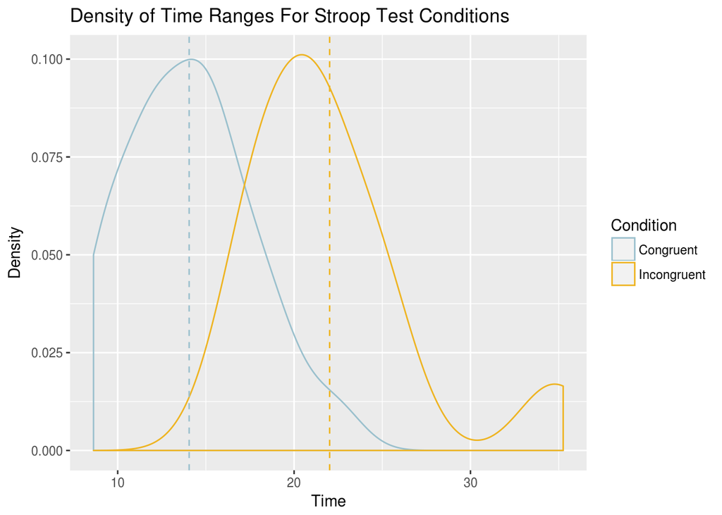

Regardless of one’s complaints, though, one might choose to consult a greater number of tests with better study designs (e.g., more test subjects, randomly selected individuals, etc.). Fortunately, this assessment has been well publicized and documented so it is arguably trivial for one to discover a trove of other studies.

## 6. Optional: What do you think is responsible for the effects observed? Can you think of an alternative or similar task that would result in a similar effect? Some research about the problem will be helpful for thinking about these two questions!

As stated previously, I believe that cognitive function plays a large role in the effects observed. The tasks may recruit common neuroanatomical regions, such as of the visual cortex, and it trivially requires more time and biological resources to execute multiple tasks simultaneously than it does to execute a single task. Further, color recognition seems a relatively autonomous function, so even though it provides contradictory information in the present circumstances, it cannot be “shut off,” if you will, and it likely involves more time and resources to (hopefully) correctly reject one source of information and deliberately select another.

It seems we may create a general description of the present assessment as follows: input two forms of infromation, either concurring with one another or contradicting one another, and have a test subject return a specific one of those two forms of information. Thus, one may contrive tasks involving cognitive functions, such as visuospatial localization (e.g., read the words “top”, “bottom”, “left”, or “right” when such words are placed in contradictory locations of the visual field), size discrimination (e.g., read the words “small”, “medium”, “large”, etc. when said words fill a contradictory amount of a bounding area, such as one’s visual field), and so on.